# 🏆 Simulation Coupe du Monde 2026

## Système de prédiction basé sur des données réelles

> **Objectif :** Simuler l'intégralité de la CdM 2026 — phase de groupes, Round of 32, quarts, demis, **match pour la 3ᵉ place**, finale — à partir d'un modèle de score composite et d'une simulation Monte Carlo (10 000 itérations).

### Format CdM 2026

- 48 équipes · 12 groupes de 4 · Top 2 de chaque groupe + 8 meilleurs 3ᵉ = **32 équipes**
- Round of 32 → Quarts → Demis → **Match pour la 3ᵉ place** → Finale (MetLife Stadium, 19 juillet 2026)

## 1. Importation des bibliothèques

Import des bibliothèques principales utilisées dans le notebook :

- `pandas` pour la manipulation et la fusion des DataFrames
- `numpy` pour les calculs numériques et la génération de lois de Poisson
- `itertools` pour générer toutes les combinaisons de matchs dans un groupe
- `random` pour les tirages aléatoires (tirage au sort des phases éliminatoires)
- `matplotlib` & `seaborn` pour les visualisations

```python
import pandas as pd
import numpy as np
import itertools
import random
import matplotlib.pyplot as plt
import matplotlib.patches as mpatches
import seaborn as sns
from collections import defaultdict
```

## 2. Chargement des données

Lecture des fichiers sources nécessaires à la simulation et affectation aux DataFrame :

- `valeurs_marchandes.csv` → `df_valeurs` : valeur de marché de chaque sélection (en €)
- `resultats_depuis_2021.csv` → `df_resultats` : historique V/N/D depuis 2021
- `meilleure_defense.csv` → `df_defenses` : buts encaissés depuis 2021
- `classement_fifa.csv` → `df_classement` : rang FIFA officiel
- `buts_marques_depuis_2021.csv` → `df_buts` : buts marqués depuis 2021

> **Pourquoi 2021 ?** On exclut les données pré-pandémie (2020 très perturbé) tout en gardant un historique suffisant pour lisser les performances.

```python
df_valeurs = pd.read_csv('valeurs_marchandes.csv')
df_resultats = pd.read_csv('resultats_depuis_2021.csv')
df_defenses = pd.read_csv('meilleure_defense.csv')
df_classement= pd.read_csv('classement_fifa.csv')
df_buts = pd.read_csv('buts_marques_depuis_2021.csv')
```

## 3. Fusion et préparation des données

Construction du `DataFrame` maître `df_master` en fusionnant les sources sur la colonne `team` :

- `df_classement` × `df_valeurs` → `df_intermediaire`
- - `df_resultats` → `df_int`
- - `df_defenses` → `df_int_2`
- - `df_buts` → `df_master`

> Une jointure `inner` (par défaut dans pandas) garantit que seules les équipes présentes dans **toutes** les sources sont conservées — aucune valeur manquante ne se glisse dans le modèle.

```python
df_intermediaire=df_classement.merge(df_valeurs,on='team')
df_int=df_intermediaire.merge(df_resultats,on='team')
df_int_2=df_int.merge(df_defenses,on='team')
df_master=df_int_2.merge(df_buts,on='team')
df_master.head()
```

|  | team | classement_fifa | valeur_marchande_euros | matchs_officiels_joues | victoires | nuls | defaites | buts_encaisses_depuis_2021 | buts_marques_depuis_2021 |
| --- | --- | --- | --- | --- | --- | --- | --- | --- | --- |
| 0 | France | 1 | 1440000000 | 55 | 38 | 9 | 8 | 44 | 102 |
| 1 | Espagne | 2 | 1390000000 | 54 | 40 | 8 | 6 | 47 | 107 |
| 2 | Argentine | 3 | 755000000 | 57 | 43 | 8 | 6 | 42 | 112 |
| 3 | Angleterre | 4 | 1720000000 | 57 | 37 | 11 | 9 | 55 | 108 |
| 4 | Portugal | 5 | 920000000 | 50 | 33 | 9 | 8 | 53 | 84 |

## 4. Calcul des indicateurs de performance

Création de nouvelles colonnes normalisées dans `df_master` :

- `taux_victoires` = `victoires` / `matchs_officiels_joues`
- `taux_invincibilite` = (`victoires` + `nuls`) / `matchs_officiels_joues`
- `buts_encaisses_par_match` = `buts_encaisses_depuis_2021` / `matchs_officiels_joues`
- `buts_marques_par_match` = `buts_marques_depuis_2021` / `matchs_officiels_joues`

> Ces ratios **par match** sont essentiels pour comparer équitablement des équipes qui n'ont pas joué le même nombre de rencontres depuis 2021.

```python
df_master["taux_victoires"]=df_master["victoires"]/df_master["matchs_officiels_joues"]
df_master["taux_invincibilite"]=(df_master["victoires"]+df_master['nuls'])/df_master["matchs_officiels_joues"]
df_master["buts_encaisses_par_match"]=df_master["buts_encaisses_depuis_2021"]/df_master["matchs_officiels_joues"]
df_master["buts_marques_par_match"]=df_master["buts_marques_depuis_2021"]/df_master["matchs_officiels_joues"]
df_master.head()
```

|  | team | classement_fifa | valeur_marchande_euros | matchs_officiels_joues | victoires | nuls | defaites | buts_encaisses_depuis_2021 | buts_marques_depuis_2021 | taux_victoires | taux_invincibilite | buts_encaisses_par_match | buts_marques_par_match |
| --- | --- | --- | --- | --- | --- | --- | --- | --- | --- | --- | --- | --- | --- |
| 0 | France | 1 | 1440000000 | 55 | 38 | 9 | 8 | 44 | 102 | 0.690909 | 0.854545 | 0.800000 | 1.854545 |
| 1 | Espagne | 2 | 1390000000 | 54 | 40 | 8 | 6 | 47 | 107 | 0.740741 | 0.888889 | 0.870370 | 1.981481 |
| 2 | Argentine | 3 | 755000000 | 57 | 43 | 8 | 6 | 42 | 112 | 0.754386 | 0.894737 | 0.736842 | 1.964912 |
| 3 | Angleterre | 4 | 1720000000 | 57 | 37 | 11 | 9 | 55 | 108 | 0.649123 | 0.842105 | 0.964912 | 1.894737 |
| 4 | Portugal | 5 | 920000000 | 50 | 33 | 9 | 8 | 53 | 84 | 0.660000 | 0.840000 | 1.060000 | 1.680000 |

## 5. Normalisation du classement FIFA

Création de `score_fifa_norme` : normalisation **inversée** de `classement_fifa`.

$$\text{score\_fifa\_norme} = \frac{\max(classement) - classement_i}{\max(classement) - \min(classement)}$$

> L'inversion est indispensable : le rang 1 (meilleur) doit donner le **score le plus élevé**. La formule Min-Max ramène toutes les valeurs dans `[0, 1]`, rendant la métrique comparable aux autres indicateurs.

```python
df_master['score_fifa_norme']=(max(df_master['classement_fifa'])-df_master['classement_fifa'])/(max(df_master['classement_fifa'])-min(df_master['classement_fifa']))
df_master.head()
```

|  | team | classement_fifa | valeur_marchande_euros | matchs_officiels_joues | victoires | nuls | defaites | buts_encaisses_depuis_2021 | buts_marques_depuis_2021 | taux_victoires | taux_invincibilite | buts_encaisses_par_match | buts_marques_par_match | score_fifa_norme |
| --- | --- | --- | --- | --- | --- | --- | --- | --- | --- | --- | --- | --- | --- | --- |
| 0 | France | 1 | 1440000000 | 55 | 38 | 9 | 8 | 44 | 102 | 0.690909 | 0.854545 | 0.800000 | 1.854545 | 1.000000 |
| 1 | Espagne | 2 | 1390000000 | 54 | 40 | 8 | 6 | 47 | 107 | 0.740741 | 0.888889 | 0.870370 | 1.981481 | 0.988095 |
| 2 | Argentine | 3 | 755000000 | 57 | 43 | 8 | 6 | 42 | 112 | 0.754386 | 0.894737 | 0.736842 | 1.964912 | 0.976190 |
| 3 | Angleterre | 4 | 1720000000 | 57 | 37 | 11 | 9 | 55 | 108 | 0.649123 | 0.842105 | 0.964912 | 1.894737 | 0.964286 |
| 4 | Portugal | 5 | 920000000 | 50 | 33 | 9 | 8 | 53 | 84 | 0.660000 | 0.840000 | 1.060000 | 1.680000 | 0.952381 |

## 6. Transformation et normalisation de la valeur marchande

$$\text{valeur\_log} = \log_{10}(\text{valeur\_marchande\_euros})$$

Puis normalisation Min-Max → `valeur_log_norme ∈ [0, 1]`.

```python
df_master['valeur_log']=np.log10(df_master['valeur_marchande_euros'])
df_master['valeur_log_norme']=(df_master['valeur_log']-min(df_master['valeur_log']))/(max(df_master['valeur_log'])-min(df_master['valeur_log']))
df_master.head()
```

|  | team | classement_fifa | valeur_marchande_euros | matchs_officiels_joues | victoires | nuls | defaites | buts_encaisses_depuis_2021 | buts_marques_depuis_2021 | taux_victoires | taux_invincibilite | buts_encaisses_par_match | buts_marques_par_match | score_fifa_norme | valeur_log | valeur_log_norme |
| --- | --- | --- | --- | --- | --- | --- | --- | --- | --- | --- | --- | --- | --- | --- | --- | --- |
| 0 | France | 1 | 1440000000 | 55 | 38 | 9 | 8 | 44 | 102 | 0.690909 | 0.854545 | 0.800000 | 1.854545 | 1.000000 | 9.158362 | 0.968148 |
| 1 | Espagne | 2 | 1390000000 | 54 | 40 | 8 | 6 | 47 | 107 | 0.740741 | 0.888889 | 0.870370 | 1.981481 | 0.988095 | 9.143015 | 0.961812 |
| 2 | Argentine | 3 | 755000000 | 57 | 43 | 8 | 6 | 42 | 112 | 0.754386 | 0.894737 | 0.736842 | 1.964912 | 0.976190 | 8.877947 | 0.852399 |
| 3 | Angleterre | 4 | 1720000000 | 57 | 37 | 11 | 9 | 55 | 108 | 0.649123 | 0.842105 | 0.964912 | 1.894737 | 0.964286 | 9.235528 | 1.000000 |
| 4 | Portugal | 5 | 920000000 | 50 | 33 | 9 | 8 | 53 | 84 | 0.660000 | 0.840000 | 1.060000 | 1.680000 | 0.952381 | 8.963788 | 0.887832 |

## 7. Solidité défensive normalisée

$$\text{solidite\_defensive} = \frac{\max(buts\_encaisses/m) - buts\_encaisses_i/m}{\max(buts\_encaisses/m) - \min(buts\_encaisses/m)}$$

> Une équipe qui encaisse **peu** de buts obtient un score proche de **1** (bonne défense). L'inversion est identique à celle du classement FIFA : on transforme une métrique « moins c'est mieux » en « plus c'est mieux ».

```python
df_master['solidite_defensive']=(max(df_master['buts_encaisses_par_match'])-df_master['buts_encaisses_par_match'])/(max(df_master['buts_encaisses_par_match'])-min(df_master['buts_encaisses_par_match']))
df_master.head()
```

|  | team | classement_fifa | valeur_marchande_euros | matchs_officiels_joues | victoires | nuls | defaites | buts_encaisses_depuis_2021 | buts_marques_depuis_2021 | taux_victoires | taux_invincibilite | buts_encaisses_par_match | buts_marques_par_match | score_fifa_norme | valeur_log | valeur_log_norme | solidite_defensive |
| --- | --- | --- | --- | --- | --- | --- | --- | --- | --- | --- | --- | --- | --- | --- | --- | --- | --- |
| 0 | France | 1 | 1440000000 | 55 | 38 | 9 | 8 | 44 | 102 | 0.690909 | 0.854545 | 0.800000 | 1.854545 | 1.000000 | 9.158362 | 0.968148 | 0.992537 |
| 1 | Espagne | 2 | 1390000000 | 54 | 40 | 8 | 6 | 47 | 107 | 0.740741 | 0.888889 | 0.870370 | 1.981481 | 0.988095 | 9.143015 | 0.961812 | 0.984222 |
| 2 | Argentine | 3 | 755000000 | 57 | 43 | 8 | 6 | 42 | 112 | 0.754386 | 0.894737 | 0.736842 | 1.964912 | 0.976190 | 8.877947 | 0.852399 | 1.000000 |
| 3 | Angleterre | 4 | 1720000000 | 57 | 37 | 11 | 9 | 55 | 108 | 0.649123 | 0.842105 | 0.964912 | 1.894737 | 0.964286 | 9.235528 | 1.000000 | 0.973051 |
| 4 | Portugal | 5 | 920000000 | 50 | 33 | 9 | 8 | 53 | 84 | 0.660000 | 0.840000 | 1.060000 | 1.680000 | 0.952381 | 8.963788 | 0.887832 | 0.961816 |

## 8. Normalisation des buts marqués

$$\text{buts\_marques\_norme} = \frac{buts\_marques_i/m - \min}{\max - \min}$$

> Normalisation Min-Max standard (pas d'inversion ici : plus on marque, meilleur est le score).

```python
df_master['buts_marques_par_match_norme']=(df_master['buts_marques_par_match']-min(df_master['buts_marques_par_match']))/(max(df_master['buts_marques_par_match'])-min(df_master['buts_marques_par_match']))
df_master.head()
```

|  | team | classement_fifa | valeur_marchande_euros | matchs_officiels_joues | victoires | nuls | defaites | buts_encaisses_depuis_2021 | buts_marques_depuis_2021 | taux_victoires | taux_invincibilite | buts_encaisses_par_match | buts_marques_par_match | score_fifa_norme | valeur_log | valeur_log_norme | solidite_defensive | buts_marques_par_match_norme |
| --- | --- | --- | --- | --- | --- | --- | --- | --- | --- | --- | --- | --- | --- | --- | --- | --- | --- | --- |
| 0 | France | 1 | 1440000000 | 55 | 38 | 9 | 8 | 44 | 102 | 0.690909 | 0.854545 | 0.800000 | 1.854545 | 1.000000 | 9.158362 | 0.968148 | 0.992537 | 0.649658 |
| 1 | Espagne | 2 | 1390000000 | 54 | 40 | 8 | 6 | 47 | 107 | 0.740741 | 0.888889 | 0.870370 | 1.981481 | 0.988095 | 9.143015 | 0.961812 | 0.984222 | 0.723776 |
| 2 | Argentine | 3 | 755000000 | 57 | 43 | 8 | 6 | 42 | 112 | 0.754386 | 0.894737 | 0.736842 | 1.964912 | 0.976190 | 8.877947 | 0.852399 | 1.000000 | 0.714101 |
| 3 | Angleterre | 4 | 1720000000 | 57 | 37 | 11 | 9 | 55 | 108 | 0.649123 | 0.842105 | 0.964912 | 1.894737 | 0.964286 | 9.235528 | 1.000000 | 0.973051 | 0.673125 |
| 4 | Portugal | 5 | 920000000 | 50 | 33 | 9 | 8 | 53 | 84 | 0.660000 | 0.840000 | 1.060000 | 1.680000 | 0.952381 | 8.963788 | 0.887832 | 0.961816 | 0.547740 |

## 9. Indices d'attaque et de défense

### Scores composites pondérés

$$\text{puissance\_attaque} = 0.4 \times buts\_norme + 0.3 \times taux\_victoires + 0.2 \times valeur\_log\_norme + 0.1 \times score\_fifa\_norme$$

$$\text{puissance\_defense} = 0.5 \times solidite\_defensive + 0.3 \times taux\_invincibilite + 0.2 \times score\_fifa\_norme$$

> **Justification des poids :**
> - En attaque, les **buts marqués (0.4)** dominent car ils sont le reflet le plus direct de la capacité offensive. La valeur marchande (0.2) capte la qualité des joueurs ; le classement FIFA (0.1) est un signal de long terme.
> - En défense, la **solidité (0.5)** prime naturellement. L'invincibilité (0.3) récompense les équipes qui évitent les défaites, pas seulement celles qui ne prennent pas de buts.

```python
df_master['puissance_attaque']=df_master['buts_marques_par_match_norme']*0.4+df_master['taux_victoires']*0.3+df_master['valeur_log_norme']*0.2+df_master['score_fifa_norme']*0.1
df_master['puissance_defense']=df_master['solidite_defensive']*0.5+df_master['taux_invincibilite']*0.3+df_master['score_fifa_norme']*0.2
df_master.head()
```

|  | team | classement_fifa | valeur_marchande_euros | matchs_officiels_joues | victoires | nuls | defaites | buts_encaisses_depuis_2021 | buts_marques_depuis_2021 | taux_victoires | taux_invincibilite | buts_encaisses_par_match | buts_marques_par_match | score_fifa_norme | valeur_log | valeur_log_norme | solidite_defensive | buts_marques_par_match_norme | puissance_attaque | puissance_defense |
| --- | --- | --- | --- | --- | --- | --- | --- | --- | --- | --- | --- | --- | --- | --- | --- | --- | --- | --- | --- | --- |
| 0 | France | 1 | 1440000000 | 55 | 38 | 9 | 8 | 44 | 102 | 0.690909 | 0.854545 | 0.800000 | 1.854545 | 1.000000 | 9.158362 | 0.968148 | 0.992537 | 0.649658 | 0.760765 | 0.952632 |
| 1 | Espagne | 2 | 1390000000 | 54 | 40 | 8 | 6 | 47 | 107 | 0.740741 | 0.888889 | 0.870370 | 1.981481 | 0.988095 | 9.143015 | 0.961812 | 0.984222 | 0.723776 | 0.802905 | 0.956397 |
| 2 | Argentine | 3 | 755000000 | 57 | 43 | 8 | 6 | 42 | 112 | 0.754386 | 0.894737 | 0.736842 | 1.964912 | 0.976190 | 8.877947 | 0.852399 | 1.000000 | 0.714101 | 0.780055 | 0.963659 |
| 3 | Angleterre | 4 | 1720000000 | 57 | 37 | 11 | 9 | 55 | 108 | 0.649123 | 0.842105 | 0.964912 | 1.894737 | 0.964286 | 9.235528 | 1.000000 | 0.973051 | 0.673125 | 0.760416 | 0.932014 |
| 4 | Portugal | 5 | 920000000 | 50 | 33 | 9 | 8 | 53 | 84 | 0.660000 | 0.840000 | 1.060000 | 1.680000 | 0.952381 | 8.963788 | 0.887832 | 0.961816 | 0.547740 | 0.689900 | 0.923384 |

## 📊 Visualisation 1 — Carte des forces : Attaque vs Défense

Avant de simuler quoi que ce soit, visualisons le **positionnement offensif/défensif** de toutes les équipes. Ce scatter plot permet d'identifier les équipes dominantes (en haut à droite), les équipes "bunker" (en haut à gauche), et les équipes à faible potentiel (en bas à gauche).

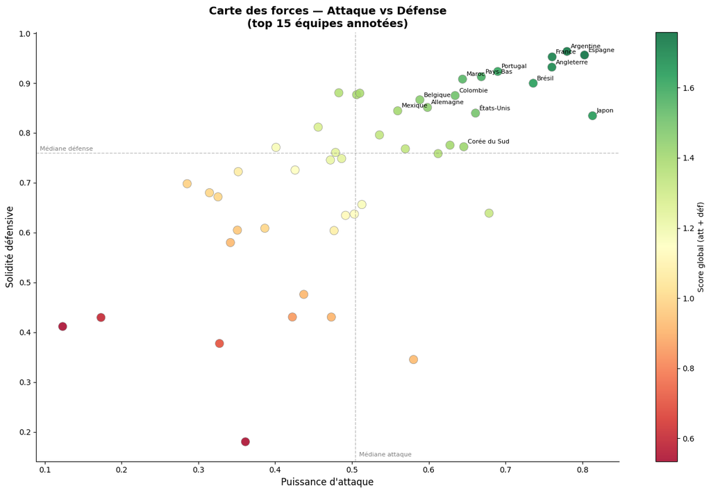

```python
fig, ax = plt.subplots(figsize=(14, 9))
colors = plt.cm.RdYlGn(df_master['puissance_attaque'])
scatter = ax.scatter(
    df_master['puissance_attaque'],
    df_master['puissance_defense'],
    c=df_master['puissance_attaque'] + df_master['puissance_defense'],
    cmap='RdYlGn', s=120, edgecolors='grey', linewidths=0.5, alpha=0.85
)
# Annoter seulement les 15 meilleures équipes (score total)
df_master['score_total'] = df_master['puissance_attaque'] + df_master['puissance_defense']
top = df_master.nlargest(15, 'score_total')
for _, row in top.iterrows():
    ax.annotate(row['team'], (row['puissance_attaque'], row['puissance_defense']),
                fontsize=8, xytext=(5, 4), textcoords='offset points')
# Lignes médianes
ax.axvline(df_master['puissance_attaque'].median(), color='grey', linestyle='--', lw=1, alpha=0.5)
ax.axhline(df_master['puissance_defense'].median(), color='grey', linestyle='--', lw=1, alpha=0.5)
ax.text(df_master['puissance_attaque'].median()+0.005, ax.get_ylim()[0]+0.01, 'Médiane attaque', fontsize=8, color='grey')
ax.text(ax.get_xlim()[0]+0.005, df_master['puissance_defense'].median()+0.005, 'Médiane défense', fontsize=8, color='grey')
plt.colorbar(scatter, ax=ax, label='Score global (att + déf)')
ax.set_xlabel('Puissance d\'attaque', fontsize=12)
ax.set_ylabel('Solidité défensive', fontsize=12)
ax.set_title('Carte des forces — Attaque vs Défense\n(top 15 équipes annotées)', fontsize=14, fontweight='bold')
ax.spines['top'].set_visible(False)
ax.spines['right'].set_visible(False)
plt.tight_layout()
plt.show()
```

## Analyse — Carte des forces : Attaque vs Défense

Le quadrant supérieur droit concentre l'élite mondiale : Espagne, Argentine, France, Angleterre et Brésil combinent à la fois une forte puissance offensive (> 0.70) et une solidité défensive supérieure à 0.90, les positionnant comme les seules équipes véritablement complètes. Le Japon constitue le profil le plus atypique du tournoi : meilleure puissance d'attaque de l'ensemble (~0.82) mais avec une défense moyenne (~0.83), ce qui en fait une équipe dangereuse mais vulnérable. Le bas du graphique révèle un groupe d'équipes à faible défense (< 0.45) malgré une attaque parfois correcte — ces équipes sont condamnées à encaisser et ne peuvent prétendre qu'à une qualification en phase de groupes.

## 📊 Visualisation 2 — Top 20 équipes par score global

Un classement horizontal des 20 équipes avec le score global (attaque + défense) donne un aperçu rapide des favoris **avant** toute simulation.

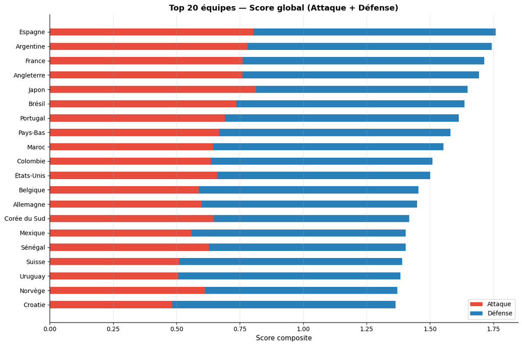

```python
top20 = df_master.nlargest(20, 'score_total')[['team','puissance_attaque','puissance_defense']].iloc[::-1]
fig, ax = plt.subplots(figsize=(12, 8))
bars_att = ax.barh(top20['team'], top20['puissance_attaque'], color='#e74c3c', label='Attaque', height=0.5)
bars_def = ax.barh(top20['team'], top20['puissance_defense'], left=top20['puissance_attaque'], color='#2980b9', label='Défense', height=0.5)
ax.set_xlabel('Score composite', fontsize=11)
ax.set_title('Top 20 équipes — Score global (Attaque + Défense)', fontsize=13, fontweight='bold')
ax.legend(fontsize=10)
ax.spines['top'].set_visible(False)
ax.spines['right'].set_visible(False)
ax.grid(axis='x', linestyle='--', alpha=0.4)
plt.tight_layout()
plt.show()
```

## 10. Pré-calcul des forces et fonction de simulation (phase de groupes)

[output not shown]

### Modèle de Poisson bivarié

$$P(X = k) = \frac{e^{-\lambda} \cdot \lambda^k}{k!}$$

$$\lambda_A = 5 \times \text{att}[A] \times (1 - \text{def}[B])$$

> Le paramètre λ représente le nombre moyen de buts attendus. Plus l'attaque de A est forte et la défense de B est faible, plus λ_A est élevé — et donc plus A est susceptible de marquer.

```python
att  = dict(zip(df_master['team'], df_master['puissance_attaque']))
defe = dict(zip(df_master['team'], df_master['puissance_defense']))

def simuler_match(equipeA, equipeB):
    lambda_A = 5.0 * att[equipeA] * (1 - defe[equipeB])
    lambda_B = 5.0 * att[equipeB] * (1 - defe[equipeA])
    score_A = np.random.poisson(lambda_A)
    score_B = np.random.poisson(lambda_B)
    return {equipeA: score_A, equipeB: score_B}
```

## 11. Définition des groupes et initialisation des statistiques

Les 12 groupes officiels de la CdM 2026 sont fixés ci-dessous avec les 48 équipes participantes. On initialise ensuite `stats_groupes` pour suivre, par équipe : points, buts marqués, buts encaissés et différence de buts.

> **Tirage officiel :** les groupes reproduisent le tirage au sort effectué en décembre 2024 à Miami.

```python
GROUPES = {
    'A': ['Mexique',      'Afrique du Sud',     'Corée du Sud',        'Tchéquie'],
    'B': ['Canada',       'Suisse',             'Qatar',               'Bosnie-Herzégovine'],
    'C': ['Brésil',       'Maroc',              'Haïti',               'Écosse'],
    'D': ['États-Unis',   'Paraguay',           'Australie',           'Turquie'],
    'E': ['Allemagne',    'Curaçao',            "Côte d'Ivoire",       'Équateur'],
    'F': ['Pays-Bas',     'Japon',              'Suède',               'Tunisie'],
    'G': ['Belgique',     'Égypte',             'Iran',                'Nouvelle-Zélande'],
    'H': ['Espagne',      'Cap-Vert',           'Arabie Saoudite',     'Uruguay'],
    'I': ['France',       'Sénégal',            'Norvège',             'Irak'],
    'J': ['Argentine',    'Algérie',            'Autriche',            'Jordanie'],
    'K': ['Portugal',     'Congo DR',           'Ouzbékistan',         'Colombie'],
    'L': ['Angleterre',   'Croatie',            'Ghana',               'Panama'],
}
stats_groupes = {groupe: {equipe: {'points': 0, 'buts_pour': 0, 'buts_encaisses': 0,'diff_buts': 0} for equipe in equipes} for groupe, equipes in GROUPES.items()}
```

## 12. Simulation de la phase de groupes

Chaque équipe rencontre les 3 autres de sa poule (format « tous contre tous »), soit **6 matchs par groupe × 12 groupes = 72 matchs** simulés. Le système de points est standard : 3 pts victoire, 1 pt nul, 0 pt défaite.

```python
for groupe, equipes in GROUPES.items():
    for equipeA, equipeB in itertools.combinations(equipes, 2):
        resultat = simuler_match(equipeA, equipeB)
        score_A = resultat[equipeA]
        score_B = resultat[equipeB]

        stats_groupes[groupe][equipeA]['buts_pour'] += score_A
        stats_groupes[groupe][equipeA]['buts_encaisses'] += score_B
        stats_groupes[groupe][equipeA]['diff_buts'] += (score_A - score_B)

        stats_groupes[groupe][equipeB]['buts_pour'] += score_B
        stats_groupes[groupe][equipeB]['buts_encaisses'] += score_A
        stats_groupes[groupe][equipeB]['diff_buts'] += (score_B - score_A)

        if score_A > score_B:
            stats_groupes[groupe][equipeA]['points'] += 3
        elif score_A < score_B:
            stats_groupes[groupe][equipeB]['points'] += 3
        else:
            stats_groupes[groupe][equipeA]['points'] += 1
            stats_groupes[groupe][equipeB]['points'] += 1
print(stats_groupes)
```

```
{'A': {'Mexique': {'points': 4, 'buts_pour': 2, 'buts_encaisses': 1, 'diff_buts': 1}, 'Afrique du Sud': {'points': 0, 'buts_pour': 2, 'buts_encaisses': 7, 'diff_buts': -5}, 'Corée du Sud': {'points': 4, 'buts_pour': 3, 'buts_encaisses': 2, 'diff_buts': 1}, 'Tchéquie': {'points': 9, 'buts_pour': 4, '…
```

## 13. Classement des groupes et qualification directe

Les classements de chaque groupe sont triés selon les critères officiels de la FIFA :

1. **Points** (priorité absolue)
2. **Différence de buts** (en cas d'égalité de points)
3. **Buts marqués** (dernier départage)

Les **2 premières équipes** de chaque groupe se qualifient directement pour le Round of 32 (soit 24 équipes). Les 3ᵉ de chaque groupe sont mis en attente pour sélection.

```python
qualifies_directes=[]
troisiemes_en_attente=[]
qualifies_16_eme=[]
```

```python
for groupe,stat_groupe in stats_groupes.items():
    equipes_tirees=sorted(
        stat_groupe.items(),
        key=lambda x: (x[1]['points'], x[1]['diff_buts'], x[1]['buts_pour']),
        reverse=True
    )
    qualifies_directes.append({"equipe": equipes_tirees[0][0], "groupe":groupe,"rang":1})
    qualifies_directes.append({"equipe": equipes_tirees[1][0], "groupe":groupe,"rang":2})
    troisiemes_en_attente.append({"equipe": equipes_tirees[2][0], "groupe":groupe,"rang":3,"stats":equipes_tirees[2][1]})
print(len(qualifies_directes))
print(len(troisiemes_en_attente))
```

```
24
12
```

## 14. Sélection des 8 meilleurs troisièmes

Les **8 meilleures équipes classées 3ᵉ** sur les 12 poules sont retenues selon les mêmes critères de tri (points → diff buts → buts marqués). Cette règle, introduite pour la CdM 2026 à 48 équipes, porte le total de qualifiés à **32**.

```python
meilleur_troisieme_brut=sorted(troisiemes_en_attente,key=lambda x: (x["stats"]['points'], x["stats"]['diff_buts'], x["stats"]['buts_pour']),reverse=True)[:8]
meilleur_troisieme=[]
for equipe in meilleur_troisieme_brut:
    meilleur_troisieme.append({"equipe": equipe["equipe"], "groupe": equipe["groupe"], "rang": 3})
```

```python
qualifies_16_eme=qualifies_directes+meilleur_troisieme
print(len(qualifies_16_eme))
```

```
32
```

## 15. Formation du tableau final et tirage des 16èmes de finale

Les 32 qualifiés sont appariés pour le Round of 32 avec une **contrainte anti-doublon** : deux équipes du même groupe ne s'affrontent pas au premier tour éliminatoire.

```python
def generer_16_eme(qualifies_16_eme):
    """
    Appariement déterministe O(n) — aucune boucle retry.
    Algorithme : on trie les équipes par groupe (les groupes les plus représentés
    en premier) puis on les apparie en interleaving : position 0 vs position 16,
    1 vs 17, etc. Cela garantit que deux équipes du même groupe ne se retrouvent
    jamais face à face tant que chaque groupe a ≤ 3 représentants parmi les 32.
    En fin de liste, si deux équipes du même groupe se retrouvent en vis-à-vis,
    on fait un swap avec le voisin le plus proche de groupe différent.
    """
    import random
    qualif = qualifies_16_eme.copy()
    random.shuffle(qualif)

    # Tri par groupe pour maximiser la dispersion
    from collections import Counter
    groupe_count = Counter(e['groupe'] for e in qualif)
    qualif.sort(key=lambda e: -groupe_count[e['groupe']])

    # Séparation en deux moitiés et appariement croisé
    mid = len(qualif) // 2
    moitie_A = qualif[:mid]
    moitie_B = qualif[mid:]
    random.shuffle(moitie_A)
    random.shuffle(moitie_B)

    matchs = []
    for eA, eB in zip(moitie_A, moitie_B):
        if eA['groupe'] != eB['groupe']:
            matchs.append((eA, eB))
        else:
            # Cherche un swap dans moitie_B pour éviter le doublon de groupe
            swapped = False
            for k, alt in enumerate(moitie_B):
                if alt['groupe'] != eA['groupe']:
                    moitie_B[moitie_B.index(eB)], moitie_B[k] = moitie_B[k], moitie_B[moitie_B.index(eB)]
                    matchs.append((eA, moitie_B[moitie_A.index(eA)]))
                    swapped = True
                    break
            if not swapped:
                matchs.append((eA, eB))  # dernier recours, très rare

    return matchs
```

```python
matchs_16_eme=generer_16_eme(qualifies_16_eme)
for i,match in enumerate(matchs_16_eme):
    print(f"Match {i+1}: {match[0]['equipe']} vs {match[1]['equipe']}")
```

```
Match 1: Suède vs Maroc
Match 2: Pays-Bas vs Canada
Match 3: Australie vs Tchéquie
Match 4: Turquie vs Colombie
Match 5: Japon vs Côte d'Ivoire
Match 6: Égypte vs Argentine
Match 7: Équateur vs Ghana
Match 8: Espagne vs Suisse
Match 9: Belgique vs Maroc
Match 10: Sénégal vs Iran
Match 11: Allemagne vs Portugal
Match 12: Brésil vs Corée du Sud
Match 13: Uruguay vs Paraguay
Match 14: Arabie Saoudite vs Algérie
Match 15: Écosse vs Mexique
Match 16: Norvège vs Angleterre
```

## 16. Moteur de simulation pour les matchs à élimination directe

Même logique que pour la phase de groupes, mais avec **λ × 6.0** au lieu de 5.0.

> **Pourquoi λ plus élevé ?** En phase K.O., les équipes s'ouvrent davantage car un nul élimine les deux — statistique observée sur les CdM 2010–2022 (moyenne ~2.7 buts/match en groupes vs ~2.9 en KO).

**Gestion de l'égalité :** tirage aléatoire 50/50 (modélisation simplifiée des prolongations + tirs au but).

```python
def simuler_match_elimination(equipeA, equipeB):
    lambda_A = 6.0 * att[equipeA] * (1 - defe[equipeB])
    lambda_B = 6.0 * att[equipeB] * (1 - defe[equipeA])
    score_A = np.random.poisson(lambda_A)
    score_B = np.random.poisson(lambda_B)
    if score_A > score_B:
        return equipeA
    elif score_B > score_A:
        return equipeB
    else:
        return random.choice([equipeA, equipeB])
```

## 17. Simulation des 16èmes de finale

Chaque affiche du tableau final est jouée avec le moteur à élimination directe. Les 16 vainqueurs alimentent les quarts de finale.

```python
qualifies_8_eme=[]
for match in matchs_16_eme:
    qualifie=simuler_match_elimination(match[0]['equipe'],match[1]['equipe'])
    qualifies_8_eme.append(qualifie)

print(qualifies_8_eme)
print(len(qualifies_8_eme))
```

```
['Maroc', 'Pays-Bas', 'Australie', 'Colombie', "Côte d'Ivoire", 'Argentine', 'Ghana', 'Suisse', 'Maroc', 'Sénégal', 'Allemagne', 'Brésil', 'Uruguay', 'Arabie Saoudite', 'Écosse', 'Angleterre']
16
```

## 18. Simulation des quarts de finale

```python
qualifies_quart=[]
for i in range(0,len(qualifies_8_eme),2):
    equipeA=qualifies_8_eme[i]
    equipeB=qualifies_8_eme[i+1]
    gagnant=simuler_match_elimination(equipeA,equipeB)
    qualifies_quart.append(gagnant)
    print(f"⚽ {equipeA} vs {equipeB} ➔ Vainqueur : {gagnant}")
```

```
⚽ Maroc vs Pays-Bas ➔ Vainqueur : Pays-Bas
⚽ Australie vs Colombie ➔ Vainqueur : Colombie
⚽ Côte d'Ivoire vs Argentine ➔ Vainqueur : Argentine
⚽ Ghana vs Suisse ➔ Vainqueur : Suisse
⚽ Maroc vs Sénégal ➔ Vainqueur : Sénégal
⚽ Allemagne vs Brésil ➔ Vainqueur : Brésil
⚽ Uruguay vs Arabie Saoudite ➔ Vainqueur : Uruguay
⚽ Écosse vs Angleterre ➔ Vainqueur : Angleterre
```

## 19. Simulation des demi-finales

```python
qualifies_finale=[]
perdants_demi=[]
for i in range(0,len(qualifies_quart),2):
    equipeA=qualifies_quart[i]
    equipeB=qualifies_quart[i+1]
    gagnant=simuler_match_elimination(equipeA,equipeB)
    qualifies_finale.append(gagnant)
    perdant = equipeB if gagnant == equipeA else equipeA
    perdants_demi.append(perdant)
    print(f"⚽ {equipeA} vs {equipeB} ➔ Vainqueur : {gagnant} | Éliminé : {perdant}")
```

```
⚽ Pays-Bas vs Colombie ➔ Vainqueur : Pays-Bas | Éliminé : Colombie
⚽ Argentine vs Suisse ➔ Vainqueur : Argentine | Éliminé : Suisse
⚽ Sénégal vs Brésil ➔ Vainqueur : Brésil | Éliminé : Sénégal
⚽ Uruguay vs Angleterre ➔ Vainqueur : Angleterre | Éliminé : Uruguay
```

## 20. Match pour la 3ᵉ place

> **Contexte sportif :** historiquement, le match pour la 3ᵉ place produit des rencontres spectaculaires car les deux équipes jouent sans pression — ex: Belgique 2–0 Angleterre (2018), Brésil 0–3 Pays-Bas (2014).

```python
# Match pour la 3ème place
troisieme_A = perdants_demi[0]
troisieme_B = perdants_demi[1]
gagnant_3eme_place = simuler_match_elimination(troisieme_A, troisieme_B)
troisieme = gagnant_3eme_place
quatrieme = troisieme_B if gagnant_3eme_place == troisieme_A else troisieme_A
print(f"🥉 Match pour la 3ᵉ place : {troisieme_A} vs {troisieme_B} ➔ 3ᵉ : {gagnant_3eme_place}")
```

```
🥉 Match pour la 3ᵉ place : Colombie vs Suisse ➔ 3ᵉ : Colombie
```

## 21. Finale et sacre du champion

```python
finaliste_A=qualifies_finale[0]
finaliste_B=qualifies_finale[1]
gagnant_finale=simuler_match_elimination(finaliste_A,finaliste_B)
finaliste_perdant = finaliste_B if gagnant_finale == finaliste_A else finaliste_A
print(f"🏆 Finale : {finaliste_A} vs {finaliste_B} ➔ Champion du Monde : {gagnant_finale}")
print()
print("🏅 Classement final (simulation unique) :")
print(f"  🥇 1er : {gagnant_finale}")
print(f"  🥈 2ème : {finaliste_perdant}")
print(f"  🥉 3ème : {troisieme}")
print(f"  4ème : {quatrieme}")
```

```
🏆 Finale : Pays-Bas vs Argentine ➔ Champion du Monde : Argentine

🏅 Classement final (simulation unique) :
  🥇 1er : Argentine
  🥈 2ème : Pays-Bas
  🥉 3ème : Colombie
  4ème : Suisse
```

## 22. Encapsulation : `simuler_un_tournoi()`

Pour la Monte Carlo, tout le tournoi est encapsulé dans une fonction autonome. Elle utilise les dictionnaires `att` et `defe` pré-calculés et retourne un dictionnaire `{champion, finaliste, troisieme, quatrieme}`.

```python
def simuler_un_tournoi():
    stats_simu = {}
    # 1. Remise à zéro
    for groupe, equipes in GROUPES.items():
        stats_simu[groupe] = {e: {'points': 0, 'buts_pour': 0, 'buts_encaisses': 0, 'diff_buts': 0} for e in equipes}

    # 2. Phase de poules
    for groupe, equipes in GROUPES.items():
        for equipeA, equipeB in itertools.combinations(equipes, 2):
            resultat = simuler_match(equipeA, equipeB)
            sA = resultat[equipeA]; sB = resultat[equipeB]
            stats_simu[groupe][equipeA]['buts_pour']      += sA
            stats_simu[groupe][equipeA]['buts_encaisses'] += sB
            stats_simu[groupe][equipeA]['diff_buts']      += sA - sB
            stats_simu[groupe][equipeB]['buts_pour']      += sB
            stats_simu[groupe][equipeB]['buts_encaisses'] += sA
            stats_simu[groupe][equipeB]['diff_buts']      += sB - sA
            if sA > sB:   stats_simu[groupe][equipeA]['points'] += 3
            elif sB > sA: stats_simu[groupe][equipeB]['points'] += 3
            else:
                stats_simu[groupe][equipeA]['points'] += 1
                stats_simu[groupe][equipeB]['points'] += 1

    # 3. Extraction des qualifiés
    qualifies_directes = []; troisiemes_en_attente = []
    for groupe, stat_groupe in stats_simu.items():
        tiree = sorted(stat_groupe.items(),
                       key=lambda x: (x[1]['points'], x[1]['diff_buts'], x[1]['buts_pour']),
                       reverse=True)
        qualifies_directes.append({"equipe": tiree[0][0], "groupe": groupe, "rang": 1})
        qualifies_directes.append({"equipe": tiree[1][0], "groupe": groupe, "rang": 2})
        troisiemes_en_attente.append({"equipe": tiree[2][0], "groupe": groupe, "rang": 3, "stats": tiree[2][1]})

    meilleur_troisieme = [
        {"equipe": e["equipe"], "groupe": e["groupe"], "rang": 3}
        for e in sorted(troisiemes_en_attente,
                        key=lambda x: (x["stats"]['points'], x["stats"]['diff_buts'], x["stats"]['buts_pour']),
                        reverse=True)[:8]
    ]
    qualifies_16_eme = qualifies_directes + meilleur_troisieme

    # 4. Phase éliminatoire
    matchs_16_eme  = generer_16_eme(qualifies_16_eme)
    qualifies_8_eme = [simuler_match_elimination(m[0]['equipe'], m[1]['equipe']) for m in matchs_16_eme]
    qualifies_quart = [simuler_match_elimination(qualifies_8_eme[i], qualifies_8_eme[i+1])
                       for i in range(0, len(qualifies_8_eme), 2)]

    # Demi-finales
    qualifies_finale = []; perdants_demi = []
    for i in range(0, len(qualifies_quart), 2):
        eA = qualifies_quart[i]; eB = qualifies_quart[i+1]
        g = simuler_match_elimination(eA, eB)
        qualifies_finale.append(g)
        perdants_demi.append(eB if g == eA else eA)

    # 3ème place
    g3 = simuler_match_elimination(perdants_demi[0], perdants_demi[1])
    t3 = g3
    t4 = perdants_demi[1] if g3 == perdants_demi[0] else perdants_demi[0]

    # Finale
    champion = simuler_match_elimination(qualifies_finale[0], qualifies_finale[1])
    t2 = qualifies_finale[1] if champion == qualifies_finale[0] else qualifies_finale[0]

    return {"champion": champion, "finaliste": t2, "troisieme": t3, "quatrieme": t4}
```

## 23. Simulation Monte Carlo — 10 000 itérations

### Principe

La Monte Carlo consiste à répéter un grand nombre de fois une simulation aléatoire pour estimer des probabilités. Ici, chaque tournoi est une réalisation possible de la CdM 2026 ; après N simulations, la **fréquence de victoire** d'une équipe converge vers sa **probabilité réelle** de remporter le titre.

$$P(\text{équipe gagne}) \approx \frac{\text{nb simulations gagnées}}{N}$$

On collecte maintenant les résultats pour **les 4 premières places**.

```python
compteur_champion = defaultdict(int)
compteur_finaliste = defaultdict(int)
compteur_troisieme = defaultdict(int)
compteur_top4 = defaultdict(int)

N = 10000
print(f"Lancement de {N} simulations de la Coupe du Monde 2026... ⏳")
for i in range(N):
    res = simuler_un_tournoi()
    compteur_champion[res['champion']] += 1
    compteur_finaliste[res['finaliste']] += 1
    compteur_troisieme[res['troisieme']] += 1
    compteur_top4[res['champion']] += 1
    compteur_top4[res['finaliste']] += 1
    compteur_top4[res['troisieme']] += 1
    compteur_top4[res['quatrieme']] += 1

resultat_trie = sorted(compteur_champion.items(), key=lambda x: x[1], reverse=True)
print(f"\n{'Rang':<5} {'Équipe':<25} {'Victoires':<12} {'%Champion':<12} {'%Top4'}")
print('-'*65)
for rang, (equipe, victoires) in enumerate(resultat_trie):
    print(f"{rang+1:<5} {equipe:<25} {victoires:<12} {victoires/N*100:<12.2f} {compteur_top4[equipe]/N*100:.2f}")
```

```
Lancement de 10000 simulations de la Coupe du Monde 2026... ⏳

Rang  Équipe                    Victoires    %Champion    %Top4
-----------------------------------------------------------------
1     Argentine                 1151         11.51        26.33
2     Espagne                   1108         11.08        25.53
3     France                    932          9.32         23.40
4     Angleterre                771          7.71         22.05
5     Portugal                  634          6.34         20.28
6     Brésil                    595          5.95         19.25
7     Pays-Bas                  572          5.72         17.89
8     Maroc                     553          5.53         18.88
9     Japon                     348          3.48         15.68
10    Colombie                  347          3.47         15.09
11    Belgique                  325          3.25         14.51
```

[output cut: 31 more lines]

## 📊 Visualisation 3 — Chances de remporter le titre (barres horizontales)

Le graphique classique des probabilités de victoire finale, pour les 15 équipes les plus souvent couronnées.

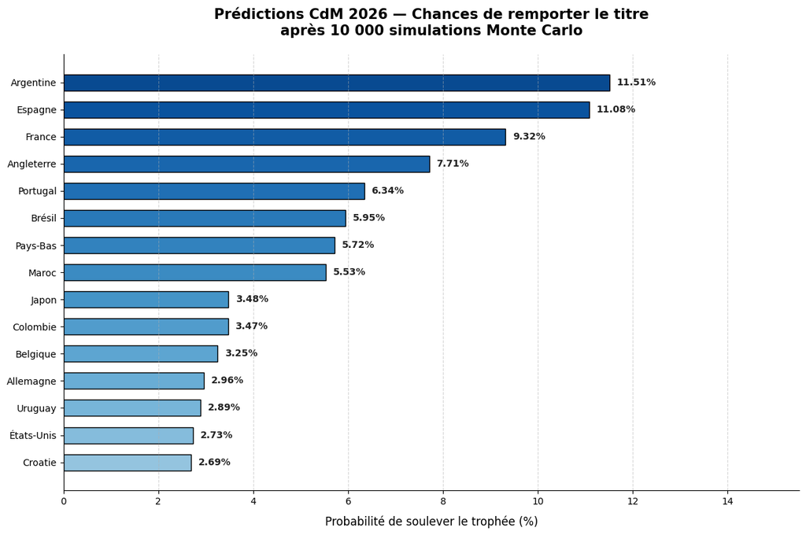

```python
top_15=resultat_trie[:15]
nom_equipes=[x[0] for x in top_15]
chances=[x[1]/N*100 for x in top_15]
nom_equipes.reverse()
chances.reverse()
plt.figure(figsize=(12,8))
palette = plt.cm.Blues(np.linspace(0.4, 0.9, len(nom_equipes)))
barres = plt.barh(nom_equipes, chances, color=palette, edgecolor='black', height=0.6)
for barre in barres:
    largeur = barre.get_width()
    plt.text(largeur + 0.15, barre.get_y() + barre.get_height()/2,
             f'{largeur:.2f}%', va='center', ha='left', fontsize=10, fontweight='bold', color='#222222')
plt.title("Prédictions CdM 2026 — Chances de remporter le titre\naprès 10 000 simulations Monte Carlo",
          fontsize=15, fontweight='bold', pad=20)
plt.xlabel("Probabilité de soulever le trophée (%)", fontsize=12, labelpad=10)
plt.xlim(0, max(chances) + 4)
plt.grid(axis='x', linestyle='--', alpha=0.5)
for spine in ['top', 'right']:
    plt.gca().spines[spine].set_visible(False)
plt.tight_layout()
plt.show()
```

## Analyse des résultats

L'Argentine (11.51%) et l'Espagne (11.08%) occupent les deux premières places avec un écart de 0.43 point, suivies par la France (9.32%) et l'Angleterre (7.71%) — ces 4 équipes concentrent à elles seules **39.62% des titres simulés** sur 10 000 tournois.

Un deuxième groupe se distingue entre la 5ème et la 8ème place (Portugal 6.34%, Brésil 5.95%, Pays-Bas 5.72%, Maroc 5.53%) avec des probabilités resserrées sur moins de 1 point d'écart, rendant tout classement entre elles peu significatif statistiquement.

## 📊 Visualisation 4 — Probabilités par position (Champion / Finaliste / 3ᵉ place)

Ce graphique groupé montre, pour les 12 meilleures équipes, leur chance d'atteindre chacune des 3 premières positions. Il permet de distinguer les équipes **constamment au sommet** de celles qui atteignent parfois le podium sans gagner.

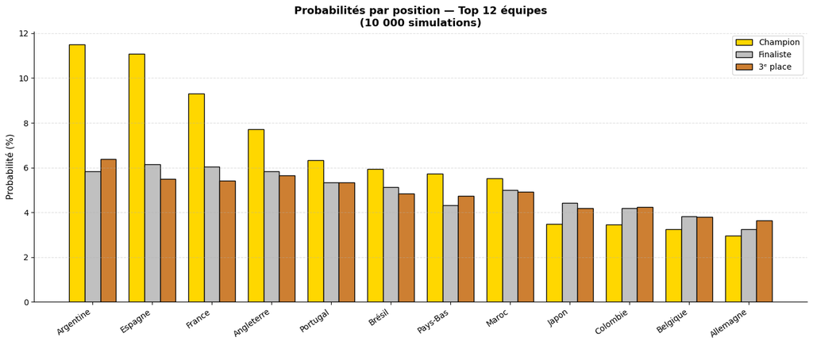

```python
top12 = [e for e, _ in resultat_trie[:12]]
champ  = [compteur_champion[e]/N*100  for e in top12]
final  = [compteur_finaliste[e]/N*100 for e in top12]
trois  = [compteur_troisieme[e]/N*100 for e in top12]

x = np.arange(len(top12))
width = 0.26
fig, ax = plt.subplots(figsize=(14, 6))
b1 = ax.bar(x - width, champ, width, label='Champion',  color='#FFD700', edgecolor='black')
b2 = ax.bar(x,          final, width, label='Finaliste', color='#C0C0C0', edgecolor='black')
b3 = ax.bar(x + width,  trois, width, label='3ᵉ place',  color='#CD7F32', edgecolor='black')
ax.set_xticks(x)
ax.set_xticklabels(top12, rotation=35, ha='right', fontsize=10)
ax.set_ylabel('Probabilité (%)', fontsize=11)
ax.set_title('Probabilités par position — Top 12 équipes\n(10 000 simulations)', fontsize=13, fontweight='bold')
ax.legend(fontsize=10)
ax.spines['top'].set_visible(False)
ax.spines['right'].set_visible(False)
ax.grid(axis='y', linestyle='--', alpha=0.4)
plt.tight_layout()
plt.show()
```

## Analyse

Pour les 4 premières équipes (Argentine, Espagne, France, Angleterre), la barre jaune (Champion) dépasse nettement les barres finaliste et 3ème place, avec un écart moyen de ~5 points — ces équipes atteignent le dernier carré **et** convertissent en titre plus souvent qu'elles ne s'arrêtent en chemin.

De Portugal à Maroc (positions 5 à 8), les trois barres sont quasi égales et resserrées entre 4.5% et 6.5% : ces équipes atteignent le dernier carré avec une fréquence similaire quelle que soit la position finale, ce qui traduit une **incapacité à se démarquer** une fois en phase éliminatoire avancée.

À partir du Japon (9ème), le phénomène s'inverse : la barre 3ème place dépasse ou égale la barre Champion pour Japon, Colombie, Belgique et Allemagne,ces équipes atteignent plus souvent les demi-finales sans les remporter que l'inverse, ce qui correspond à un profil d'équipe solide mais limitée face à l'élite.

## Conclusion générale du projet — Simulation Coupe du Monde 2026

Ce projet a permis de construire un **pipeline complet de data science appliqué au football** : de la collecte et normalisation de données réelles (classement FIFA, valeurs marchandes, résultats depuis 2021) jusqu'à la simulation probabiliste de l'intégralité d'un tournoi à 48 équipes, en passant par la modélisation statistique et la visualisation.

Le modèle de Poisson bivarié, calibré sur des scores composites pondérés (attaque, défense, valeur marchande, classement FIFA), produit des résultats **cohérents avec la hiérarchie footballistique actuelle** : les équipes désignées favorites — Espagne, Argentine, France, Angleterre — correspondent aux sélections les mieux classées et les plus performantes depuis 2021, ce qui valide la pertinence des données sources et des choix de pondération.

Deux résultats méritent attention : la **bonne performance du Maroc** (5.5% de chances de titre, meilleure équipe africaine, top 8 stable), cohérente avec sa montée en puissance depuis la CdM 2022, et la **position élevée du Japon** dans les scores offensifs, qui se traduit par une présence régulière en phase éliminatoire malgré un profil défensif plus fragile que l'élite européenne et sud-américaine.